# Einführung in die angewandte Sozialstrukturanalyse

Teil 3: Anwendung - Fertilität

Autor:in

Carsten Sauer, Jule Adriaans

# 1 Anwedungskapitel: Fertilität

## 1.1 Einleitung

## 1.2 Theorie

## 1.3 Empirie

## 1.4 Anwendungsbeispiel: Fertilität

*Anbindung an Theorieteil*

**Fragestellung:** Welches Alter gilt in Europa in der subjektiven Vorstellung als *ideal*, um Eltern zu werden und wie hat sich diese Vorstellung über die Zeit verändert? Gibt es dabei Unterschiede zwischen dem als ideal wahrgenommenen Alter für Männer um Vater und für Frauen um Mutter zu werden? Außerdem wollen wir untersuchen, ob das ideale Alter mit dem tatsächlichen Alter bei der Geburt des ersten Kindes in Zusammenhang steht.

### 1.4.1 Daten, Variablen, Methoden

**Daten:** Das European Social Survey (ESS) hat sowohl in seiner dritten als auch in seiner neunten Erhebungswelle — durchgeführt 2006 und 2018 - ein spezielles Fragebogenmodul zum Thema *Timing of life* eingesetzt, welches auch eine Frage zum subjektiv wahrgenommenen idealen Alter, um Eltern zu werden beinhaltet. Das ESS wird in vielen europäischen Ländern durchgeführt. Für unsere Analyse können wir auf Informationen aus 21 Ländern zurückgreifen, in denen sowohl 2006 als auch 2018 Daten erhoben wurden. Die Länder sind Österreich (AT), Belgien (BE), Bulgarien (BG), die Schweiz (CH), Zypern (CY), Deutschland (DE), Dänemark (DK), Estland (EE), Spanien (ES), Finnland (FI), Frankreich (FR), Großbritannien (GB), Ungarn (HU), Irland (IE), Niederlande (NL), Norwegen (NO), Polen (PL), Portugal (PT), Schweden (SE), Slowenien (SI) und die Slowakei (SK). Da wir die Vorstellungen zum *idealen* Alter auch in Zusammenhang mit dem tatsächliche Alter bei der Geburt setzen wollen, benötigen wir zusätzlich noch Informationen zum Alter bei der Geburt des ersten Kindes sowohl für das Jahr 2006 als auch 2018. Diese Informationen stammen von der [UNECE](https://w3.unece.org/PXWeb/en/Table?IndicatorCode=34) — der Wirtschaftskommission für Europa der Vereinten Nationen.

**Variablen:** Die Befragten wurden mit Hilfe folgender Frage, um ihre Einschätzung des idealen Alters um Eltern zu werden gebeten: *Was ist Ihrer Meinung nach das ideale Alter für ein Mädchen oder eine Frau, um Mutter zu werden?* Dabei wurde die Hälfte der Befragten zu ihren Vorstellungen über das ideale Alter für Frauen und die andere Hälfte über das ideale Alter für Männer befragt. Die Zuteilung — ob über Frauen oder Männer gefragt wurde — erfolgte dabei zufällig. Die Abfrage für das ideale Alter um Vater zu werden lautete: *Was ist Ihrer Meinung nach das ideale Alter für einen Jungen oder einen Mann, um Vater zu werden?* Die Befragten wurden gebeten ein Alter anzugeben oder konnten alternativ auch angeben, dass es kein ideales Alter gibt. Zur Berechnung des *idealen Alters* wird die Antwort *kein ideales Alter* nicht berücksichtigt. Als Makro-Indikator auf Länderebene verwenden wir das Durchschnittsalter von Frauen bei der Geburt des ersten Kindes in den jeweiligen Ländern.

**Methoden:** In einem ersten Schritt wollen wir feststellen, ob sich das als ideal wahrgenommen Alter um Eltern zu werden voneinander unterscheidet, je nachdem ob, Befragte, dass ideale Alter von Frauen oder Männern einschätzen sollten. In einem zweiten Schritt wollen wir dann testen, ob sich das ideale Alter — für Männer und Frauen getrennt — zwischen 2006 und 2018 verändert hat. Für beide Analysen greifen wir auf t-Tests für unabhängige Stichproben zurück, um zu prüfen, ob sich die gruppenspezifischen Mittelwerte statistisch signifikant voneinander unterscheiden. In einem dritten Schritt, wollen wir dann den Zusammenhang zwischen dem durchschnittlichen Alter von Müttern bei der Geburt des ersten Kindes auf der Länderebene mit dem durchschnittlichen idealen Alter für Frauen, um Mütter zu werden in Verbindung setzen. Dafür berechnen wir die Korrelation zwischen diesen beiden Informationen und lassen uns ein *Scatterplot* ausgeben, um den Zusammenhang grafisch darzustellen. Da wir in diesem dritten Analyseschritt den Zusammenhang zwischen zwei Variablen auf Länderebene untersuchen — das durchschnittliche ideale Alter und das durchschnittliche tatsächliche Alter — bereiten wir dafür einen Datensatz vor, der nur die aggregierten Informationen und nicht mehr die Individualdaten beinhaltet.

**Hinweise zur Datenaufbereitung:** Für unsere Analyse müssen wir mehrere Datensätze zusammenführen. Für die Analyse von Unterschieden über die Zeit und zwischen den Geschlechtern, die auf Individualdaten basieren, müssen wir lediglich die ESS3 und ESS9 Datensätze zusammenspielen. Im Anschluss bereiten wir die zentrale abhängige Variable für die Auswertung vor. Zunächst definieren wir die Antwortoption *kein ideales Alter* sowie unplausible Werte (wir definieren hier ein ideales Alter unter 15 Jahren als unplausibel) als fehlende Werte und genieren eine neue Variable *alter_ideal*. Dann bilden wir noch einen Dummy-Indikator *split*, der angibt, ob Befragte, zum idealen Alter für Väter (=0) oder für Mütter (=1) befragt wurden. Für die Analyse auf Länderebene reduzieren wir den Datensatz auf Ländermittelwerte zum idealen Alter von Müttern. Anschließend müssen wir dann noch die Makro-Indikatoren anspielen — dafür ist es entscheidend, dass die Makro-Indikatoren den richtigen Ländern und Jahren zugeordnet werden. Entsprechend müssen sowohl im Surveydatensatz als auch im Datensatz mit den Makro-Indikatoren, Informationen zum Erhebungsjahr sowie zum Land im gleichen Format vorliegen. In diesem Fall müssen wir dafür die Ländercodes erst in ein gemeinsames Format bringen.

*Code zur Aufbereitung der Individualdaten*

```r
## ESS-Daten aus Welle 3 einlesen, einschränken auf bestimmte Länder und Variablen
ess3 <- read_dta("N:/00-Buch-Sozialstruktur/3-Heterogenitäten-und-Ungleichheiten/Fertilität/ESS3e03_7.dta") |>
  select("icsbfm", "iagpnt", "cntry") |>
  filter(!cntry %in% c("CZ", "HR", "IS", "IT", "LT", "LV", "ME", "RS", "RU", "UA"))

## Variablen rekodieren und Jahres-Indikator generieren
ess3 <- ess3 |>
    mutate(
      split = ifelse(icsbfm == 1, "Mutter",
              ifelse(icsbfm == 2, "Vater", NA)),  # Split-Variable, die angibt, ob Personen zu Müttern/Vätern befragt wurden
      alter_ideal = ifelse(iagpnt >= 15 & iagpnt <= 88, iagpnt, NA),
      year = 2006,
      )

## ESS-Daten aus Welle 9 einlesen, einschränken auf bestimmte Länder und Variablen
ess9 <- read_dta("N:/00-Buch-Sozialstruktur/3-Heterogenitäten-und-Ungleichheiten/Fertilität/ESS9e03_2.dta") |>
  select("admge", "iagpnt", "cntry") |>
  filter(!cntry %in% c("CZ", "HR", "IS", "IT", "LT", "LV", "ME", "RS", "RU", "UA"))

## Variablen rekodieren und Jahres-Indikator generieren
ess9 <- ess9 |>
    mutate(
      split = ifelse(admge == 1, "Mutter",
              ifelse(admge == 2, "Vater", NA)),  # Split-Variable, die angibt, ob Personen zu Müttern/Vätern befragt wurden
      alter_ideal = ifelse(iagpnt >= 15 & iagpnt <= 88, iagpnt, NA),
      year = 2018,
      )

## Datensätze aus ESS3 und ESS9 zusammenspielen
ess_trend <- bind_rows(ess3, ess9)

## Fälle löschen bei denen Informationen zum experimentellen Split fehlen
ess_trend <- ess_trend |>
  filter(!is.na(split))
```

*Code zur Aufbereitung der Makro-Indikatoren*

```r
## Datensatz auf Angaben zum idealen Alter für Mütter eingrenzen
ess_mother <- ess_trend  |>
  filter(split == "Mutter")

## Datensatz nur mit länderspezifischen Mittelwerten, getrennt nach Jahren
ess_collapse <- ess_mother |>
  group_by(year, cntry) |>
  summarise(
    alter_ideal = mean(alter_ideal, na.rm = TRUE),  # Mittelwert
    .groups = "drop"
  )

## Datensatz mit Übersetzung von Ländercodes von 2-stellig auf 3-stellig anspielen
# Dafür müssen wir zunächst die Übersetzungsliste aus einer CSV-Datei einlesen und so umbenennen,
# dass wir sie an die ESS Daten anspielen können

codes_merge <- read_delim("N:/00-Buch-Sozialstruktur/3-Heterogenitäten-und-Ungleichheiten/Fertilität/countries-codes.csv", delim = ";", col_names = TRUE, show_col_types = FALSE)

codes_merge <- codes_merge |>
  mutate(
    cntry = `ISO2 CODE`,
    cntry_iso3 = `ISO3 CODE`
  )

ess_collapse <- ess_collapse |>
  left_join(select(codes_merge, cntry, cntry_iso3), by = "cntry")

## Makro-Indikatoren der UNECE aus csv Datei einlesen
unece_makro <- read_csv("N:/00-Buch-Sozialstruktur/3-Heterogenitäten-und-Ungleichheiten/Fertilität/data_20250319114401.csv", show_col_types = FALSE)

## Variablen umbennen und für das Anspielen an die ESS-Daten vorbereiten
unece_makro <- unece_makro |>
  mutate(
    cntry_iso3 = Alpha3Code,
    value = Value,
    alter_geburt = ifelse(value == "..", NA, as.numeric(value)),
    year = PeriodCode
  )

## Makro-Indikatoren an die ESS-Daten anspielen. Es werden nur jene Länder-Jahres-Kombinationen angespielt, die in den ESS-Daten vorhanden sind
ess_collapse <- ess_collapse |>
  left_join(unece_makro, by = c("cntry_iso3", "year"))
```

### 1.4.2 Ergebnisse

Wie oben bereits beschrieben, erfolgt unsere Analyse in drei Schritten:

1. **Gibt es Unterschiede im idealen Alter zwischen Männern und Frauen, um Eltern zu werden?**

Zunächst lassen wir uns die gruppenspezifischen Mittelwerte und Standardfehler — getrennt für die Jahre 2006 und 2018 — ausgeben. In Tabelle 1 können wir direkt erkennen, dass das durchschnittliche Alter, dass für Frauen als ideal bewertet wird, um Mutter zu werden mit rund 25 Jahren (bzw. 26 Jahren in 2018) rund zwei Jahre unter dem als ideal bewerten Alter von rund 27 Jahren (bzw. 28 Jahre in 2018) für Väter liegt. Mithilfe von t-Tests, können wir nun prüfen, ob dieser Geschlechterunterschied statistisch signifikant ist (siehe Tabelle 2). In der Tat, sowohl in 2006 ($t=-48.36, p<.001$) als auch in 2018 ($t=-45.83, p<.001$) ist der Unterschied im durchschnittlichen idealen Alter um Eltern zu werden zwischen Müttern und Vätern statistisch signifikant.

```r
age_mean <- ess_trend |>
  group_by(year, split) |>
  summarise(
    Mittelwert = mean(alter_ideal, na.rm = TRUE),  # Mittelwert
    Standardabweichung = sd(alter_ideal, na.rm = TRUE), # Standardabweichung
    Fallzahl = n(), # Fallzahl
    .groups = "drop"
  )

kable(age_mean, digits = 2, col.names = c("Jahr", "Split", "Mittelwert", "Standardabweichung", "Fallzahl"),  table.attr = 'data-quarto-disable-processing = "true"') |>
kable_styling("striped", full_width = FALSE)
```

Tabelle 1: Mittelwerte und Standardabweichungen: Ideales Alter um Eltern zu werden

| Jahr | Split | Mittelwert | Standardabweichung | Fallzahl |
| --- | --- | --- | --- | --- |
| 2006 | Mutter | 25.22 | 3.32 | 19378 |
| 2006 | Vater | 27.02 | 3.51 | 19182 |
| 2018 | Mutter | 26.17 | 3.49 | 18022 |
| 2018 | Vater | 28.04 | 3.77 | 17682 |

```r
mean_test <- ess_trend |>
  group_by(year) |>  # Gruppierung  nach Jahr
    summarise(
    t_test = list(t.test(alter_ideal ~ split, var.equal = TRUE)),  # Two-sample t-test
    .groups = "drop"
  )

mean_test <- mean_test |>
  mutate(
    t = sapply(t_test, function(x) x$statistic),  # t-Wert
    p = sapply(t_test, function(x) x$p.value)     # p-Wert
  ) |>
  select(-t_test)  # Entfernen der Liste, da nicht mehr benötigt

kable(mean_test, digits = 2, col.names = c("Jahr", "t-Wert", "p-Wert")) |>
kable_styling("striped", full_width = FALSE)
```

Tabelle 2: T-test: Unterschied im idealen Alter zwischen Müttern und Vätern

| Jahr | t-Wert | p-Wert |
| --- | --- | --- |
| 2006 | -48.36 | 0 |
| 2018 | -45.83 | 0 |

```r
mean_test <- ess_trend |>
  group_by(split) |>  # Gruppierung nach experimentellem Split
    summarise(
    t_test = list(t.test(alter_ideal ~ year, var.equal = TRUE)),  # Two-sample t-test
    .groups = "drop"
  )

mean_test <- mean_test |>
  mutate(
    t = sapply(t_test, function(x) x$statistic),  # t-Wert
    p = sapply(t_test, function(x) x$p.value)     # p-Wert
  ) |>
  select(-t_test)  # Entfernen der Liste, da nicht mehr benötigt

kable(mean_test, digits = 2, col.names = c("Split", "t-Wert", "p-Wert")) |>
kable_styling("striped", full_width = FALSE)
```

Tabelle 3: T-test: Unterschied im idealen Alter zwischen 2006 und 2018

| Split | t-Wert | p-Wert |
| --- | --- | --- |
| Mutter | -25.47 | 0 |
| Vater | -25.20 | 0 |

3. **Besteht — auf Länderbene — ein Zusammenhang zwischen dem subjektiven idealen Alter, um Mutter zu werden, und dem tatsächlichen Alter von Müttern bei der Geburt des ersten Kindes?**

Um diese Frage zu beantworten, greifen wir zusätzlich zu den ESS-Surveydaten auf Makro-Indikatoren zum durchschnittlichen Alter bei der Geburt des ersten Kindes zurück, die wir an unsere Surveydaten angespielt haben. Außerdem haben wir den Datensatz so reduziert, dass wir statt der Individualdaten nur länderspezifische Mittelwerte vorliegen haben — das bedeutet, für jedes Land liegt jeweils nur ein Eintrag für 2006 und ein Eintrag für 2018 vor (siehe Kapitel 1.4.1). Mit Hilfe von *Scatterplots* — auch Punktwolken genannt — können wir den Zusammenhang auf Länderebene grafisch darstellen. Wie schon in Tabelle 1 zu sehen, sehen wir auch in Abbildung 1 eine Verschiebung des idealen Alters nach oben: Die Punktwolke verschiebt sich für alle Länder auf der y-Achse — auf welcher das ideale Alter abgetragen wird — in Richtung eines höheren idealen Alters. Auch für Deutschland ist ein deutlicher ,,Sprung” zu beobachten. Während das als ideal bewertete Alter 2006 noch bei rund 25 Jahren lag, liegt es heute bei 27 Jahre. Den höchsten Durchschnittswert im idealen Alter um Mutter zu werden finden wir 2018 in der Schweiz — mit rund 28 Jahren — und den niedrigsten Wert 2006 in Estland — mit rund 23 Jahren. Aber nicht nur beim idealen Alter sind Veränderungen über die Zeit zu beobachten. Die Punktwolke wandert nicht nur auf der y-Achse von unten nach oben, sondern, eben auch auf der x-Achse — welche das tatsächliche Alter bei der Geburt des ersten Kindes abzeichnet — nach rechts. Außerdem können wir in Abbildung 1 ablesen, dass das ideale Alter durchweg unter dem tatsächlichen Alter bei der Geburt des ersten Kindes liegt. Die tatsächlichen Verhältnisse weichen also von den normativen Vorstellungen ab.

Da wir uns vor allem für den Zusammenhang zwischen den beiden Variablen interessieren, schauen wir nun, ob sich ein Muster in der Punktwolke erkennen lässt. Würden wir versuchen, eine Gerade durch die Punktwolke zu legen, die möglichst viele der Punkte durchkreuzt bzw. einen möglichst geringen Abstand zu möglichst vielen der Punkte aufweist, dann würde diese Gerade einen positiven Zusammenhang nachzeichnen: je höher das tatsächliche Alter, desto höher auch das ideale Alter.

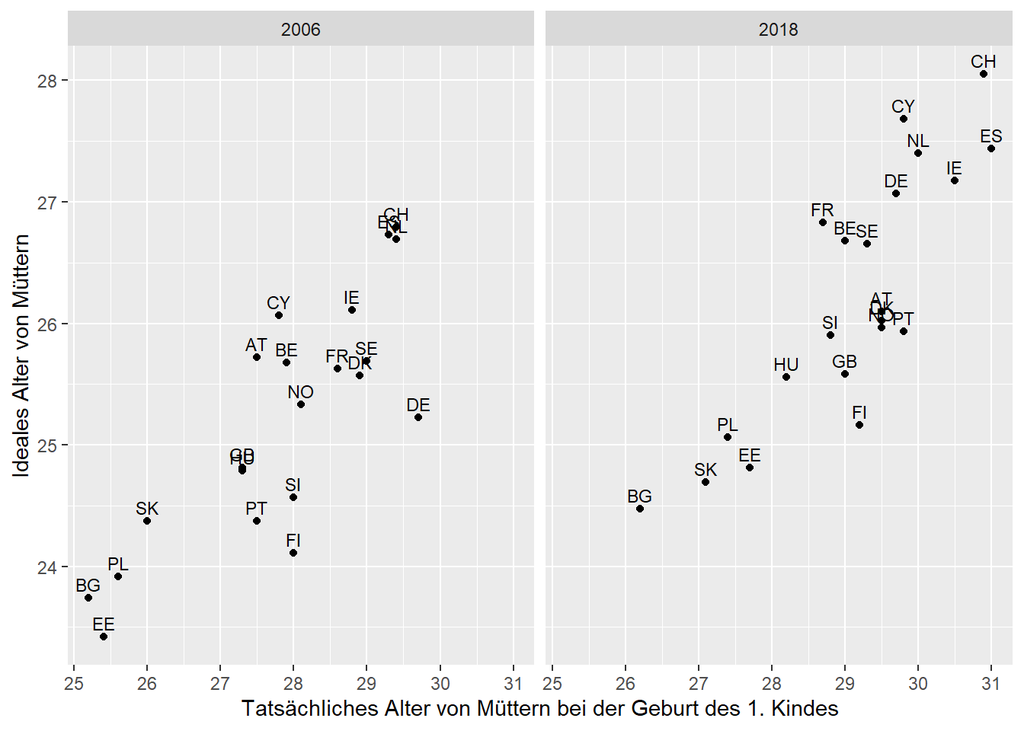

Abbildung 1: Zusammenhang zwischen tatsächlichem und idealem Alter, um Mutter zu werden

```r
# Scatterplot erstellen, getrennt nach dem Erhebungsjahr
ggplot(ess_collapse, aes(x = alter_geburt, y = alter_ideal)) +
  geom_point() +
  geom_text(aes(label = cntry), vjust = -0.5, hjust = 0.5, size = 3) +  # Punkte mit Ländernamen labeln
  facet_wrap(~ year) +
  labs(x = "Tatsächliches Alter von Müttern bei der Geburt des 1. Kindes",
       y = "Ideales Alter von Müttern")
```

Bisher haben wir den Zusammenhang vor allem grafisch untersucht. Im Folgenden werden wir nun noch Korrelationen — getrennt nach 2006 und 2018 — berechnen, um zu testen, ob ein statistisch signifikanter Zusammenhang zwischen dem idealen und dem tatsächlichen Alter besteht sowie Abbildung 1 es suggeriert und wie stark dieser Zusammenhang ist. Sowohl in 2006 ($\rho = .82, p = <.001$) als auch in 2018 ($\rho = .85, p = <.001$) besteht ein starker und positiver Zusammenhang zwischen dem tatsächlichen und idealen Alter, um Mutter zu werden (siehe Tabelle 4).

```r
# Korrelation berechnen

year2006 <- ess_collapse |>
  filter(year == 2006)

year2018 <- ess_collapse |>
  filter(year == 2018)

corr2006 <- cor.test(year2006$alter_geburt, year2006$alter_ideal, method = "pearson")

rho <- corr2006$estimate
p <- corr2006$p.value

corr2006 <- data.frame(
  Jahr = 2006,
  Rho = rho,
  p_Wert = p
)

corr2018 <- cor.test(year2018$alter_geburt, year2018$alter_ideal, method = "pearson")

rho <- corr2018$estimate
p <- corr2018$p.value

corr2018 <- data.frame(
  Jahr = 2018,
  Rho = rho,
  p_Wert = p
)

corr_ideal_real <- rbind(corr2006, corr2018)
kable(corr_ideal_real, digits = 2, row.names = F, col.names = c("Jahr", "Rho", "p-Wert")) |>
kable_styling("striped", full_width = FALSE)
```

Tabelle 4: Korrelation zwischen tatsächlichem und idealen Alter, um Mutter zu werden

| Jahr | Rho | p-Wert |
| --- | --- | --- |
| 2006 | 0.82 | 0 |
| 2018 | 0.85 | 0 |

### 1.4.3 Diskussion

- Diskussion der Ergebnisse, u.a., Makro-Makro Korrelation erlaubt keine Rückschluss über Richtung oder Ursachen des Zusammenhangs (Verweis auf Grundlagenkapitel und Makro-Mikro-Makro Modell)
- Verweis auf weitereführende Literatur